# Self-Attention

- Show All Code
- Hide All Code
- View Source

Basic Theory

Theoretical knowledge of self-attention mechanisms

Author

Wu Hao

Published

2024/12/30

This blog refers to [Self-Attention](https://speech.ee.ntu.edu.tw/~hylee/ml/2023-spring.php) and (Vaswani 2017)

## Introduction

In the project Recognize Handwritten Digits by CNN, we used a CNN network to do the classification. And in the project COVID-19 Cases Prediction, which is a regression task, we directly used a full connected layer to make the predictions. They’re similar in some ways. We could think of their input as a vector, and our output is either a scalar in the regression tasks or a category in the classification tasks.

But what should we do when we’re dealing with a bunch of different vectors, and the number of vectors can change? And even the size of the vectors is different.

```
flowchart LR
  A(a vector) --> B{Model}
  B --> C(Scalar or Class)

  D(a set of vectors) --> E{Model}
  E --> F(Scalars or Classes)
```

[output not shown]

## Vector Set as Input

### Text

Supposed that our input is a sentence. They’re different lengths, and they have different numbers of vocabularies. We can describe each vocabulary as a vector, so our input will be a set of vectors.

There are two methods we can represent our vocabularies as vectors.

1. One-Hot Encoding
2. Word Embedding: Give each word a vector containing semantic information. The embeddings of similar lexical words are similar.

### Speech

We intercept a range from the speech, called *Window*. We can describe the window as a vector which called *Frame*. In general, the length of window is 25ms.

In the project Phoneme Classification, we did a such task.

### Graph

We can think of a node in a graph as a vector. For example, in a social network, we can take each person’s profile—like age, profession, and so on—as a vector.

## What’s the output?

1. Each vector has a corresponding label.
2. An intact sequence only has one label.
3. The model should decide the number of labels in the output by itself.

## Sequence Labeling

Can we just use the fully connected network with each word as the input? It’s clearly not ideal because we’re not taking the context semantic information into account. In the project Phoneme Classification, we concatenate the current frame with its context, and feed it into a full-connected network.

But, when we face a problem that requires us to consider a whole sequence, how can we solve it? We cannot handle it with the method in phoneme classification, since the length of the sequence is different.

That’s why we introduce **Self-Attention** in here.

## Self-Attention (star)

```
flowchart LR
  A(Sequence) --> B(Self-attention)
  B --> C(word1 with context)
  B --> D(word2 with context)
  B --> E(word3 with context)
  B --> F(word4 with context)
  C --> G(FC) --> K( )
  D --> H(FC) --> L( )
  E --> I(FC) --> M( )
  F --> J(FC) --> N( )
```

[output not shown]

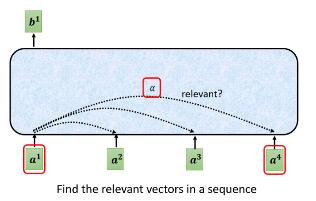

fig1

As the figures shown in fig1, in the self-attention, $b^1$ is generated by considering all the inputs $a$. It’s the same as the phoneme classification. But, how does self-attention produce $b^1$?

There is a special mechanism in here. We find out which parts of the sequence are important and relevant for $a^1$, which parts can determine the categorization of $a^1$, etc. We define $\alpha$ as the degree of relevance of $a^1$.

How to calculate $\alpha$? (shown in fig2)

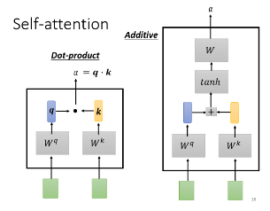

fig2

1. Dot Product

Two input vectors are multiplied by two different matrices, the left vector is multiplied by the matrix $W^Q$ to get the matrix $Q$, the right vector is multiplied by the matrix $W^K$ to get the matrix $K$. Then $Q$ and $K$ are dot-produced, that is, element-wise multiplied, and then added together to get a scalar $\alpha$.

2. Additive

Two vectors through the $W^Q$ and $W^K$ get $Q$ and $K$, and then thrown to through an Activation Function and a Transform, and then get a scalar $\alpha$.

We are likely to use the first method. Fig3 shows the details of calculating $b^1$.

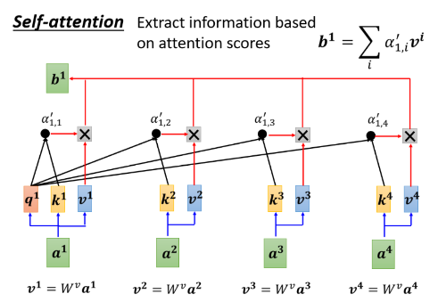

fig3

Let’s calculate the whole process.

### Query, Key and Value

`Query` indicates what each element needs to focus on.

`Key` represents what each element can provide.

`Value` represents the information that each element provides to other elements.

And their calculation is as follows:

$$\begin{align*}
Q &= A W^Q \in \mathbb{R}^{n \times d_k}, \\
K &= A W^K \in \mathbb{R}^{n \times d_k}, \\
V &= A W^V \in \mathbb{R}^{n \times d_v}
\end{align*}$$

where $A$ denotes the input matrix, and $W$ denotes the weight matrix obtained by training.

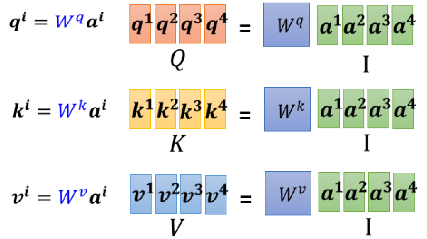

Query, Key and Value

### Attention Scores - $\alpha$

$$\begin{align*}
\text{Attention}(Q, K)=\frac{Q K^T}{\sqrt{d_k}}
\end{align*}$$

In general, we will access a softmax behind Attention Scores. So, its calculation shows as follows:

$$\begin{align*}
\text{Attention\_weights}(Q, K) &= \text{Softmax} \left( \frac{Q K^T}{\sqrt{d_k}} \right)
\end{align*}$$

The process shows in Attention Scores.

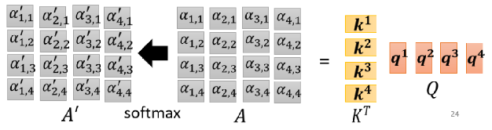

Attention Scores

### Output Matrix - $B$

$$\begin{align*}
\text{Output}=\text{Attention\_weights}\cdot V
\end{align*}$$

The process shows in Output Matrix.

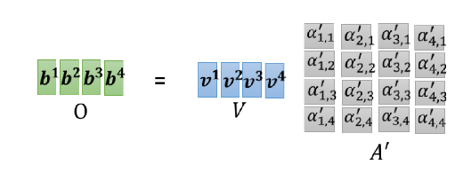

Output Matrix

### The Whole Process

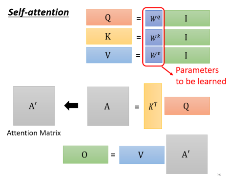

Whole Process

Back to top

## References

Vaswani, A. 2017. “Attention Is All You Need.” *Advances in Neural Information Processing Systems*.